# Longfin Smelt Occurrence by Life Stage

Brian Mahardja

2022-11-03

## Load and process Longfin Smelt data

Grab Longfin Smelt data from the integrated fish dataset (LTMRdata package by Sam Bashevkin et al.) and produce one fish data per row. I will exclude fish with no length measurement. Note that unmeasured fish that were collected alongside measured fish were converted to have fish length per LTMRdata documentation. I converted count to integer however, since the process that Sam implemented created decimal points for counts.

Surveys included in this calculation:

1. San Francisco Bay Study
2. Suisun Marsh Study
3. Fall Midwater Trawl
4. Spring Kodiak Trawl
5. Delta Juvenile Fish Monitoring Program
6. Enhanced Delta Smelt Monitoring
7. 20-mm Survey
8. Smelt Larval Survey
9. Summer Townet Survey

```r
#Use deltafish to load data
surv <- open_survey()
fish <- open_fish()

# filter for taxa of interest
fish_longfinsmelt <- fish %>%
  filter(Taxa %in% c("Spirinchus thaleichthys"))


# do a join and collect the resulting data frame
# collect executes the sql query and gives you a table
data_longfinsmelt<-left_join(surv, fish_longfinsmelt) %>%
  collect()


#Create time series summary
data_longfinsmelt_time_summary<-data_longfinsmelt %>% group_by(Source) %>% summarise(StartDate=min(Date),EndDate=max(Date))
data_longfinsmelt_time_summary
```

```
## # A tibble: 9 x 3
##   Source    StartDate  EndDate
##   <chr>     <date>     <date>
## 1 20mm      1995-04-24 2021-07-16
## 2 Bay Study 1980-01-23 2020-12-01
## 3 DJFMP     1976-03-08 2020-12-31
## 4 EDSM      2016-12-15 2021-03-25
## 5 FMWT      1967-09-13 2020-12-15
## 6 SKT       2002-01-07 2021-04-29
## 7 SLS       2009-01-05 2021-03-17
## 8 STN       1959-06-14 2021-08-19
## 9 Suisun    1979-05-16 2021-09-23
```

```r
#Remove 0 counts, only use years 1994 and after, only ones with non-zero lengths
data_longfinsmelt <- data_longfinsmelt %>%
  filter(Count>0) %>% filter(year(Date)>=1994) %>% filter(!is.na(Length))

#Change count to integer
data_longfinsmelt$Count<-as.integer(data_longfinsmelt$Count)
#Remove zero catch data
data_longfinsmelt<- data_longfinsmelt%>% filter(Count>0)

#Create long form, remove data prior to 1994
data_longfinsmelt_long <-data_longfinsmelt[rep(1:nrow(data_longfinsmelt), data_longfinsmelt$Count),] %>% mutate(Count=1)
```

## Regions used to understand spatial distribution

Shown below are the regional cutoffs used to better understand when fish are found in a particular area within the estuary

```
## # A tibble: 13 x 1
##    SubRegion
##    <chr>
##  1 San Joaquin River at Twitchell Island
##  2 San Joaquin River at Prisoners Pt
##  3 Franks Tract
##  4 Holland Cut
##  5 Middle River
##  6 Upper San Joaquin River
##  7 Victoria Canal
##  8 Grant Line Canal and Old River
##  9 San Joaquin River near Stockton
## 10 Old River
## 11 Disappointment Slough
## 12 Rock Slough and Discovery Bay
## 13 Mildred Island
```

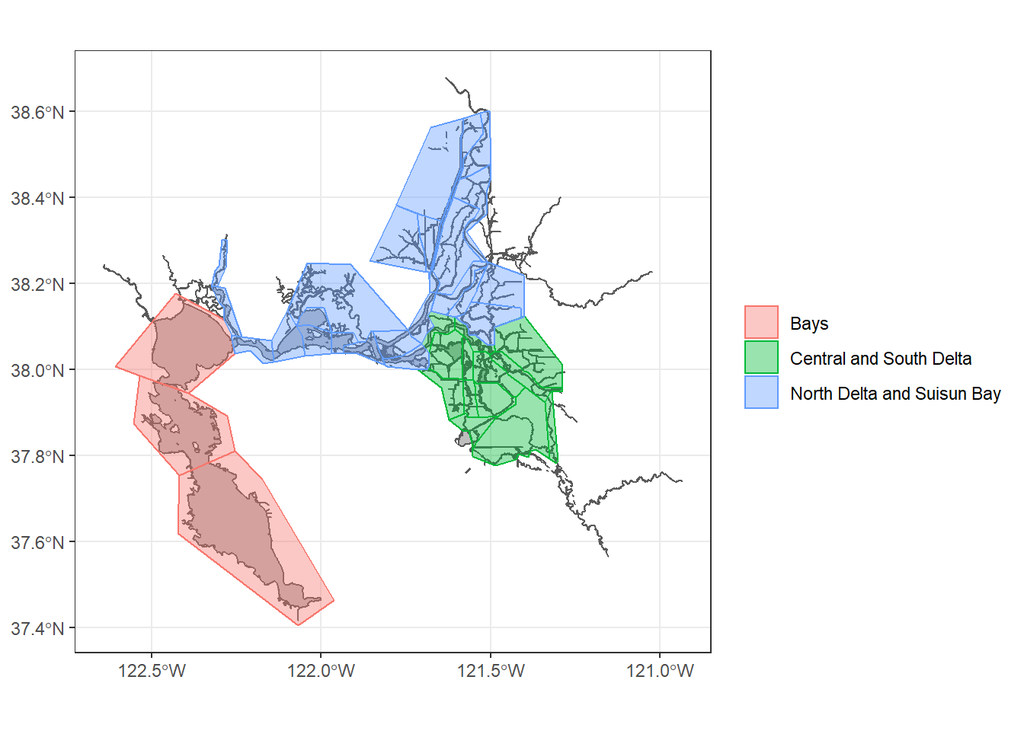

## Create spatial data frame, categorizing fish catch into regions

## Size cutoffs used for Longfin Smelt

Larvae: (<20mm FL)

Juvenile: (20-84mm FL)

Adult: (>84mm FL)

### Brood year cutoff for the life stages

Larvae: brood year = calendar year

Juvenile: brood year = calendar year

Adult: brood year starts in July 1st of current year to June 30th of the following year

# Overview of size distribution

Subadult and adult Longfin Smelt typically are present and caught from January to July, and then again starting October to November.

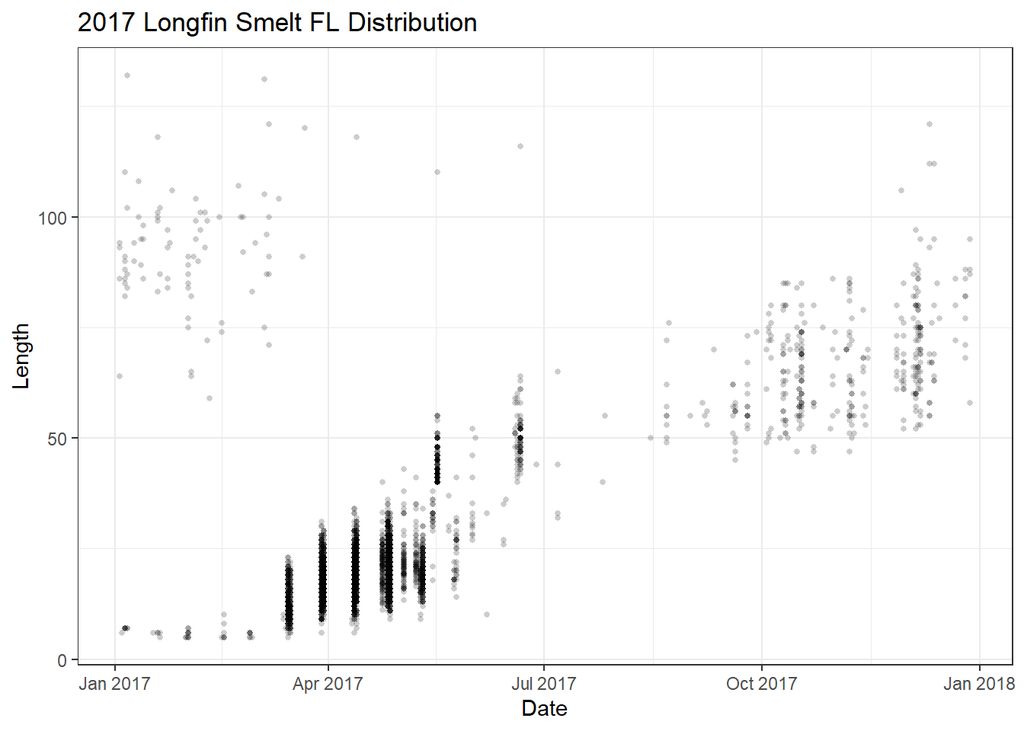

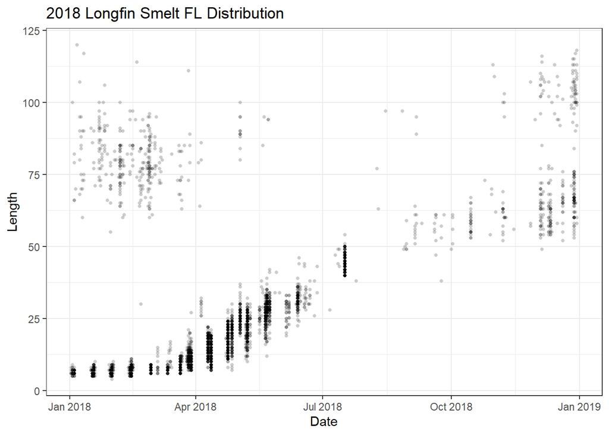

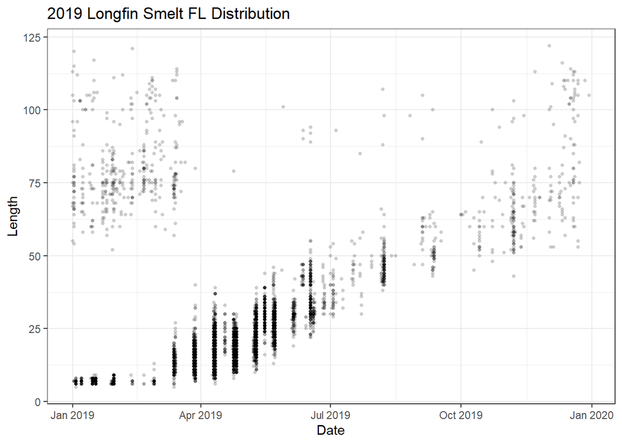

## Adult Longfin Smelt

(mature and immature adults of >84 mm FL, cohort year set to July 1st - June 30th)

## Juvenile Longfin Smelt

(20-84 mm FL, cohort year set to January 1st - December 31st; same as calendar year)

## Larval Longfin Smelt

(<20 mm FL, cohort year set to just calendar year)

## Bay Region

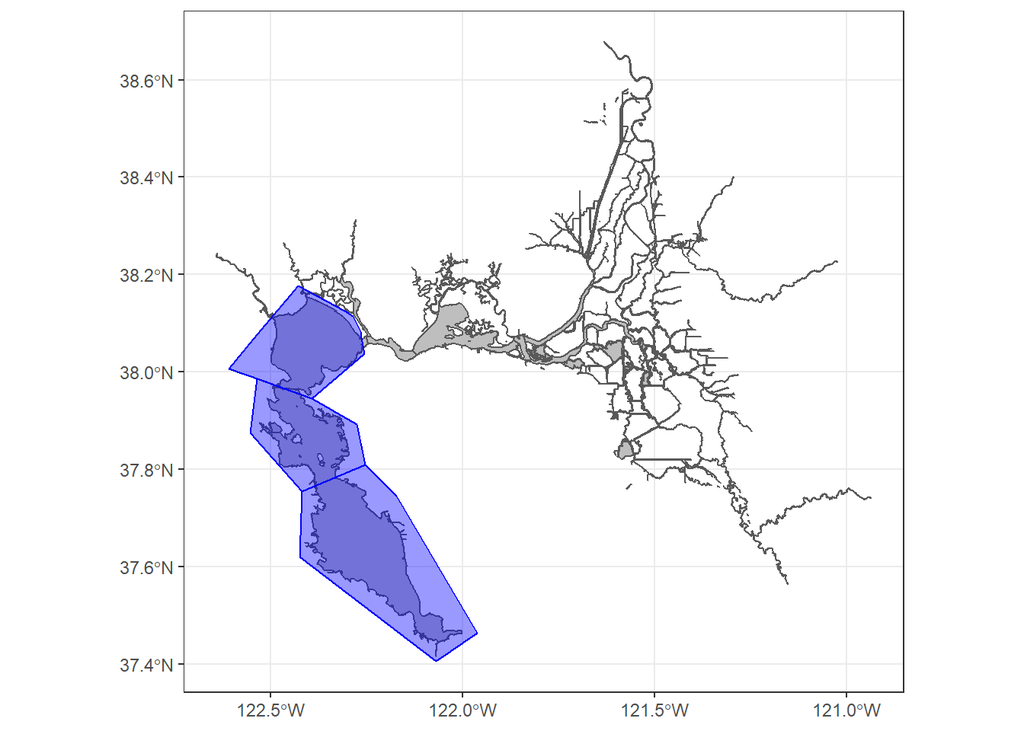

### Adults

| Cohort Year | 0.0% | 5.0% | 10.0% | 90.0% | 95.0% | 100.0% | Sample size |
| --- | --- | --- | --- | --- | --- | --- | --- |
| 1994 | July 06 1994 | September 12 1994 | November 07 1994 | May 03 1995 | May 04 1995 | May 09 1995 | 80 |
| 1995 | July 10 1995 | July 10 1995 | January 08 1996 | June 06 1996 | June 10 1996 | June 10 1996 | 203 |
| 1996 | July 03 1996 | August 12 1996 | November 06 1996 | April 14 1997 | May 12 1997 | June 10 1997 | 439 |
| 1997 | July 09 1997 | September 08 1997 | November 05 1997 | May 11 1998 | May 11 1998 | June 08 1998 | 181 |
| 1998 | November 02 1998 | December 03 1998 | December 07 1998 | May 27 1999 | June 09 1999 | June 15 1999 | 173 |
| 1999 | July 08 1999 | July 12 1999 | July 12 1999 | April 05 2000 | May 10 2000 | June 13 2000 | 119 |
| 2000 | July 07 2000 | August 24 2000 | December 12 2000 | April 16 2001 | May 10 2001 | June 07 2001 | 196 |
| 2001 | July 17 2001 | October 25 2001 | November 14 2001 | April 04 2002 | April 04 2002 | May 14 2002 | 154 |
| 2002 | September 09 2002 | December 04 2002 | January 08 2003 | June 02 2003 | June 25 2003 | June 25 2003 | 114 |
| 2003 | July 17 2003 | August 07 2003 | October 14 2003 | April 15 2004 | May 05 2004 | May 11 2004 | 67 |
| 2004 | September 09 2004 | September 09 2004 | December 06 2004 | June 09 2005 | June 09 2005 | June 13 2005 | 62 |
| 2005 | July 11 2005 | October 05 2005 | November 08 2005 | May 06 2006 | May 18 2006 | June 14 2006 | 95 |
| 2006 | July 19 2006 | September 07 2006 | November 08 2006 | May 14 2007 | May 14 2007 | June 05 2007 | 65 |
| 2007 | July 11 2007 | July 11 2007 | August 08 2007 | March 05 2008 | June 05 2008 | June 05 2008 | 15 |
| 2008 | August 07 2008 | November 05 2008 | December 02 2008 | April 13 2009 | May 06 2009 | June 03 2009 | 62 |
| 2009 | July 13 2009 | July 13 2009 | July 13 2009 | March 08 2010 | March 10 2010 | May 12 2010 | 41 |
| 2010 | July 08 2010 | December 06 2010 | January 13 2011 | May 04 2011 | May 04 2011 | June 08 2011 | 39 |
| 2011 | July 07 2011 | October 10 2011 | December 07 2011 | April 09 2012 | May 10 2012 | June 07 2012 | 77 |
| 2012 | July 05 2012 | July 10 2012 | September 06 2012 | March 11 2013 | June 11 2013 | June 11 2013 | 46 |
| 2013 | July 03 2013 | July 03 2013 | July 09 2013 | February 11 2014 | May 19 2014 | May 19 2014 | 19 |
| 2014 | December 03 2014 | December 03 2014 | December 03 2014 | May 12 2015 | May 12 2015 | May 12 2015 | 7 |
| 2016 | December 12 2016 | December 12 2016 | December 12 2016 | June 21 2017 | June 21 2017 | June 21 2017 | 8 |
| 2017 | October 31 2017 | October 31 2017 | November 29 2017 | February 27 2018 | February 28 2018 | February 28 2018 | 16 |
| 2018 | December 06 2018 | December 06 2018 | December 06 2018 | June 12 2019 | June 17 2019 | June 17 2019 | 10 |
| 2019 | July 22 2019 | July 22 2019 | August 07 2019 | February 03 2020 | February 03 2020 | February 03 2020 | 17 |
| 2020 | September 23 2020 | September 23 2020 | September 23 2020 | November 12 2020 | November 12 2020 | November 12 2020 | 5 |

### Juveniles

| Cohort Year | 0.0% | 5.0% | 10.0% | 90.0% | 95.0% | 100.0% | Sample size |
| --- | --- | --- | --- | --- | --- | --- | --- |
| 1994 | February 04 1994 | February 04 1994 | February 04 1994 | December 05 1994 | December 05 1994 | December 05 1994 | 288 |
| 1995 | January 05 1995 | May 04 1995 | May 09 1995 | September 11 1995 | November 14 1995 | December 13 1995 | 14009 |
| 1996 | January 08 1996 | January 08 1996 | February 14 1996 | December 09 1996 | December 11 1996 | December 12 1996 | 1390 |
| 1997 | January 07 1997 | February 04 1997 | March 04 1997 | December 01 1997 | December 01 1997 | December 09 1997 | 969 |
| 1998 | January 06 1998 | February 11 1998 | May 08 1998 | November 02 1998 | December 02 1998 | December 08 1998 | 3927 |
| 1999 | January 13 1999 | February 08 1999 | April 21 1999 | September 07 1999 | September 30 1999 | November 29 1999 | 6184 |
| 2000 | January 24 2000 | February 09 2000 | March 24 2000 | November 17 2000 | December 12 2000 | December 15 2000 | 2352 |
| 2001 | January 10 2001 | January 10 2001 | January 10 2001 | September 10 2001 | October 31 2001 | December 11 2001 | 425 |
| 2002 | February 14 2002 | March 14 2002 | April 06 2002 | November 06 2002 | December 04 2002 | December 09 2002 | 638 |
| 2003 | January 08 2003 | January 09 2003 | January 09 2003 | December 01 2003 | December 03 2003 | December 18 2003 | 428 |
| 2004 | January 07 2004 | January 07 2004 | January 13 2004 | December 06 2004 | December 07 2004 | December 14 2004 | 432 |
| 2005 | January 05 2005 | January 05 2005 | January 11 2005 | October 11 2005 | December 13 2005 | December 20 2005 | 402 |
| 2006 | January 09 2006 | April 22 2006 | April 22 2006 | September 05 2006 | October 04 2006 | December 11 2006 | 7929 |
| 2007 | January 08 2007 | January 08 2007 | January 08 2007 | September 13 2007 | October 10 2007 | December 05 2007 | 308 |
| 2008 | January 28 2008 | June 05 2008 | June 10 2008 | December 02 2008 | December 04 2008 | December 04 2008 | 237 |
| 2009 | January 07 2009 | January 12 2009 | January 13 2009 | July 13 2009 | October 12 2009 | December 09 2009 | 243 |
| 2010 | January 06 2010 | January 19 2010 | February 09 2010 | December 06 2010 | December 06 2010 | December 09 2010 | 151 |
| 2011 | January 12 2011 | February 10 2011 | March 14 2011 | December 05 2011 | December 07 2011 | December 12 2011 | 1386 |
| 2012 | January 05 2012 | January 05 2012 | January 05 2012 | November 06 2012 | November 06 2012 | December 10 2012 | 328 |
| 2013 | January 09 2013 | January 09 2013 | February 06 2013 | December 04 2013 | December 09 2013 | December 10 2013 | 334 |
| 2014 | January 13 2014 | January 13 2014 | January 13 2014 | November 12 2014 | December 04 2014 | December 09 2014 | 66 |
| 2015 | January 07 2015 | January 07 2015 | January 07 2015 | June 09 2015 | October 12 2015 | October 12 2015 | 31 |
| 2016 | May 04 2016 | May 04 2016 | May 04 2016 | September 07 2016 | November 29 2016 | December 13 2016 | 32 |
| 2017 | February 09 2017 | March 29 2017 | March 29 2017 | July 07 2017 | October 17 2017 | December 13 2017 | 1083 |
| 2018 | February 26 2018 | February 27 2018 | May 29 2018 | December 10 2018 | December 11 2018 | December 11 2018 | 406 |
| 2019 | January 14 2019 | March 13 2019 | March 27 2019 | September 12 2019 | November 07 2019 | December 11 2019 | 945 |
| 2020 | January 28 2020 | June 23 2020 | July 27 2020 | November 05 2020 | November 05 2020 | December 01 2020 | 321 |
| 2021 | February 22 2021 | February 22 2021 | February 22 2021 | February 22 2021 | February 22 2021 | February 22 2021 | 1 |

### Larvae

| Cohort Year | 0.0% | 5.0% | 10.0% | 90.0% | 95.0% | 100.0% | Sample size |
| --- | --- | --- | --- | --- | --- | --- | --- |
| 1995 | April 28 1995 | April 28 1995 | April 28 1995 | May 26 1995 | May 26 1995 | June 09 1995 | 146 |
| 1996 | April 14 1996 | April 14 1996 | April 14 1996 | April 17 1996 | April 17 1996 | May 29 1996 | 2759 |
| 1997 | April 18 1997 | April 18 1997 | April 18 1997 | April 18 1997 | April 18 1997 | April 18 1997 | 14 |
| 1998 | April 10 1998 | April 10 1998 | April 10 1998 | May 08 1998 | May 08 1998 | June 05 1998 | 398 |
| 1999 | April 15 1999 | April 15 1999 | April 15 1999 | May 13 1999 | May 13 1999 | June 25 1999 | 43 |
| 2000 | March 24 2000 | March 24 2000 | March 24 2000 | May 04 2000 | May 04 2000 | September 11 2000 | 298 |
| 2001 | March 23 2001 | March 23 2001 | March 23 2001 | April 06 2001 | April 06 2001 | April 20 2001 | 26 |
| 2002 | March 22 2002 | March 22 2002 | March 22 2002 | March 22 2002 | June 01 2002 | June 01 2002 | 13 |
| 2004 | April 15 2004 | April 15 2004 | April 15 2004 | April 15 2004 | April 15 2004 | April 15 2004 | 1 |
| 2005 | April 02 2005 | April 02 2005 | April 02 2005 | April 29 2005 | April 29 2005 | April 29 2005 | 8 |
| 2006 | March 24 2006 | April 22 2006 | April 22 2006 | May 06 2006 | May 19 2006 | May 19 2006 | 7006 |
| 2007 | March 30 2007 | March 30 2007 | March 30 2007 | April 13 2007 | April 13 2007 | April 13 2007 | 6 |
| 2008 | March 20 2008 | March 20 2008 | March 20 2008 | March 20 2008 | March 20 2008 | March 20 2008 | 3 |
| 2009 | March 13 2009 | March 13 2009 | March 13 2009 | March 26 2009 | April 24 2009 | May 08 2009 | 31 |
| 2010 | March 17 2010 | March 17 2010 | March 17 2010 | April 14 2010 | April 14 2010 | May 26 2010 | 37 |
| 2011 | March 17 2011 | April 25 2011 | April 25 2011 | April 25 2011 | April 25 2011 | May 10 2011 | 2972 |
| 2012 | March 14 2012 | March 14 2012 | March 14 2012 | May 23 2012 | May 23 2012 | May 23 2012 | 7 |
| 2013 | April 10 2013 | April 10 2013 | April 10 2013 | April 24 2013 | April 24 2013 | April 24 2013 | 8 |
| 2017 | March 15 2017 | March 15 2017 | March 15 2017 | April 26 2017 | April 26 2017 | May 10 2017 | 1530 |
| 2018 | March 28 2018 | March 28 2018 | March 28 2018 | March 28 2018 | March 28 2018 | March 28 2018 | 1 |
| 2019 | March 13 2019 | March 13 2019 | March 27 2019 | April 24 2019 | April 24 2019 | May 22 2019 | 1784 |

## North Delta and Suisun Bay Region

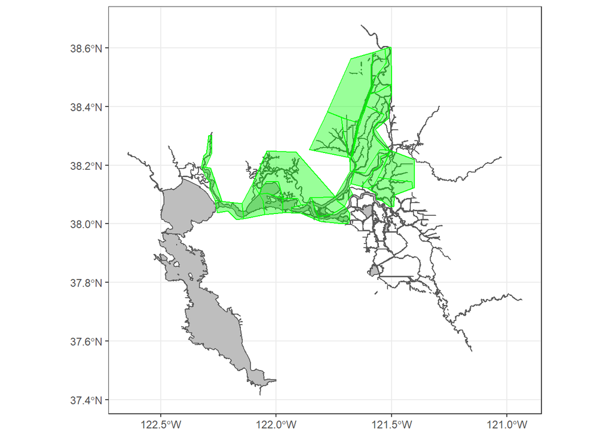

### Adults

| Cohort Year | 0.0% | 5.0% | 10.0% | 90.0% | 95.0% | 100.0% | Sample size |
| --- | --- | --- | --- | --- | --- | --- | --- |
| 1994 | July 03 1994 | November 28 1994 | December 07 1994 | February 10 1995 | March 06 1995 | June 12 1995 | 1981 |
| 1995 | August 09 1995 | January 03 1996 | January 03 1996 | May 13 1996 | May 13 1996 | June 27 1996 | 2025 |
| 1996 | July 10 1996 | December 08 1996 | December 17 1996 | January 23 1997 | March 03 1997 | June 30 1997 | 11754 |
| 1997 | July 15 1997 | December 05 1997 | December 09 1997 | January 12 1998 | January 27 1998 | June 03 1998 | 1904 |
| 1998 | September 16 1998 | December 07 1998 | December 09 1998 | May 19 1999 | June 08 1999 | June 16 1999 | 1431 |
| 1999 | July 07 1999 | December 02 1999 | December 16 1999 | March 06 2000 | May 09 2000 | June 14 2000 | 2847 |
| 2000 | July 11 2000 | December 06 2000 | December 15 2000 | March 19 2001 | April 02 2001 | June 13 2001 | 1897 |
| 2001 | July 03 2001 | December 12 2001 | December 19 2001 | January 22 2002 | March 04 2002 | June 18 2002 | 6764 |
| 2002 | July 10 2002 | December 19 2002 | December 24 2002 | January 22 2003 | January 31 2003 | June 24 2003 | 1900 |
| 2003 | July 14 2003 | December 13 2003 | December 17 2003 | January 12 2004 | March 02 2004 | June 30 2004 | 4968 |
| 2004 | July 07 2004 | December 07 2004 | December 16 2004 | January 26 2005 | February 14 2005 | June 23 2005 | 1447 |
| 2005 | July 25 2005 | December 07 2005 | December 09 2005 | February 09 2006 | February 22 2006 | April 21 2006 | 732 |
| 2006 | July 17 2006 | November 11 2006 | December 12 2006 | April 20 2007 | May 06 2007 | June 13 2007 | 216 |
| 2007 | August 13 2007 | December 01 2007 | December 11 2007 | February 12 2008 | March 03 2008 | April 02 2008 | 744 |
| 2008 | October 16 2008 | December 08 2008 | December 09 2008 | March 18 2009 | April 09 2009 | June 25 2009 | 389 |
| 2009 | July 07 2009 | December 09 2009 | December 16 2009 | March 10 2010 | March 15 2010 | May 27 2010 | 593 |
| 2010 | October 07 2010 | December 17 2010 | December 17 2010 | January 12 2011 | February 09 2011 | June 07 2011 | 251 |
| 2011 | August 02 2011 | November 01 2011 | December 05 2011 | March 06 2012 | March 13 2012 | June 05 2012 | 252 |
| 2012 | September 10 2012 | December 12 2012 | December 17 2012 | January 11 2013 | February 19 2013 | May 13 2013 | 1089 |
| 2013 | September 09 2013 | November 12 2013 | November 13 2013 | February 26 2014 | March 13 2014 | May 15 2014 | 126 |
| 2014 | September 03 2014 | December 10 2014 | December 19 2014 | March 03 2015 | April 07 2015 | June 08 2015 | 121 |
| 2015 | July 10 2015 | July 10 2015 | September 17 2015 | February 12 2016 | February 22 2016 | February 24 2016 | 20 |
| 2016 | November 08 2016 | December 07 2016 | December 19 2016 | March 01 2017 | March 06 2017 | March 22 2017 | 82 |
| 2017 | October 10 2017 | November 07 2017 | December 06 2017 | May 03 2018 | May 03 2018 | May 23 2018 | 113 |
| 2018 | August 15 2018 | November 08 2018 | December 04 2018 | March 05 2019 | March 15 2019 | June 17 2019 | 181 |
| 2019 | July 05 2019 | October 28 2019 | December 04 2019 | March 02 2020 | March 12 2020 | June 11 2020 | 103 |
| 2020 | July 07 2020 | September 15 2020 | October 15 2020 | February 12 2021 | March 03 2021 | April 29 2021 | 38 |
| 2021 | September 23 2021 | September 23 2021 | September 23 2021 | September 23 2021 | September 23 2021 | September 23 2021 | 1 |

### Juveniles

| Cohort Year | 0.0% | 5.0% | 10.0% | 90.0% | 95.0% | 100.0% | Sample size |
| --- | --- | --- | --- | --- | --- | --- | --- |
| 1994 | January 03 1994 | January 11 1994 | March 08 1994 | June 14 1994 | June 17 1994 | December 31 1994 | 10263 |
| 1995 | January 03 1995 | April 28 1995 | May 12 1995 | December 06 1995 | December 20 1995 | December 28 1995 | 9228 |
| 1996 | January 03 1996 | January 04 1996 | January 11 1996 | June 29 1996 | July 29 1996 | December 30 1996 | 15906 |
| 1997 | January 17 1997 | April 04 1997 | April 05 1997 | December 06 1997 | December 20 1997 | December 31 1997 | 11208 |
| 1998 | January 03 1998 | April 10 1998 | April 10 1998 | November 24 1998 | December 15 1998 | December 31 1998 | 24423 |
| 1999 | January 01 1999 | April 15 1999 | April 16 1999 | August 16 1999 | October 05 1999 | December 31 1999 | 41724 |
| 2000 | January 02 2000 | April 06 2000 | April 07 2000 | June 21 2000 | September 13 2000 | December 20 2000 | 64002 |
| 2001 | January 03 2001 | February 06 2001 | March 24 2001 | May 30 2001 | June 03 2001 | December 31 2001 | 25079 |
| 2002 | January 02 2002 | March 22 2002 | March 22 2002 | June 15 2002 | October 20 2002 | December 31 2002 | 20473 |
| 2003 | January 02 2003 | March 26 2003 | March 28 2003 | May 22 2003 | October 13 2003 | December 31 2003 | 8436 |
| 2004 | January 02 2004 | January 27 2004 | February 11 2004 | August 03 2004 | December 09 2004 | December 31 2004 | 4440 |
| 2005 | January 02 2005 | January 05 2005 | January 24 2005 | June 09 2005 | October 07 2005 | December 28 2005 | 2407 |
| 2006 | January 10 2006 | March 24 2006 | March 24 2006 | October 11 2006 | November 15 2006 | December 31 2006 | 1364 |
| 2007 | January 03 2007 | January 09 2007 | January 22 2007 | May 26 2007 | June 07 2007 | December 30 2007 | 1162 |
| 2008 | January 02 2008 | March 19 2008 | March 19 2008 | June 04 2008 | June 18 2008 | December 24 2008 | 11480 |
| 2009 | January 02 2009 | March 12 2009 | March 26 2009 | June 11 2009 | June 16 2009 | December 23 2009 | 2672 |
| 2010 | January 05 2010 | March 16 2010 | March 17 2010 | May 13 2010 | May 25 2010 | December 06 2010 | 4972 |
| 2011 | January 05 2011 | March 16 2011 | April 14 2011 | June 30 2011 | December 05 2011 | December 30 2011 | 4531 |
| 2012 | January 03 2012 | February 07 2012 | March 27 2012 | June 13 2012 | June 27 2012 | December 21 2012 | 1589 |
| 2013 | January 04 2013 | April 09 2013 | April 09 2013 | June 04 2013 | June 11 2013 | December 11 2013 | 20106 |
| 2014 | January 06 2014 | March 19 2014 | March 20 2014 | May 15 2014 | June 18 2014 | December 31 2014 | 1315 |
| 2015 | January 02 2015 | January 06 2015 | January 07 2015 | May 12 2015 | May 26 2015 | June 09 2015 | 434 |
| 2016 | February 03 2016 | March 10 2016 | March 30 2016 | May 11 2016 | May 24 2016 | December 27 2016 | 760 |
| 2017 | January 03 2017 | March 30 2017 | March 30 2017 | October 18 2017 | December 05 2017 | December 28 2017 | 1283 |
| 2018 | January 04 2018 | February 07 2018 | March 22 2018 | August 09 2018 | December 20 2018 | December 30 2018 | 1676 |
| 2019 | January 01 2019 | March 28 2019 | April 11 2019 | June 06 2019 | June 26 2019 | December 23 2019 | 4328 |
| 2020 | January 03 2020 | April 06 2020 | April 23 2020 | June 17 2020 | June 22 2020 | December 28 2020 | 1667 |
| 2021 | January 04 2021 | April 07 2021 | April 07 2021 | May 19 2021 | May 19 2021 | August 11 2021 | 5990 |

### Larvae

| Cohort Year | 0.0% | 5.0% | 10.0% | 90.0% | 95.0% | 100.0% | Sample size |
| --- | --- | --- | --- | --- | --- | --- | --- |
| 1994 | March 18 1994 | March 18 1994 | March 18 1994 | April 24 1994 | April 24 1994 | April 24 1994 | 4 |
| 1995 | April 27 1995 | April 27 1995 | April 27 1995 | May 12 1995 | May 25 1995 | June 27 1995 | 386 |
| 1996 | April 12 1996 | April 13 1996 | April 16 1996 | May 13 1996 | May 14 1996 | June 29 1996 | 9816 |
| 1997 | April 03 1997 | April 04 1997 | April 04 1997 | April 30 1997 | April 30 1997 | June 01 1997 | 8349 |
| 1998 | April 10 1998 | April 10 1998 | April 10 1998 | April 10 1998 | April 10 1998 | June 19 1998 | 10706 |
| 1999 | April 14 1999 | April 15 1999 | April 15 1999 | April 30 1999 | May 14 1999 | July 23 1999 | 28318 |
| 2000 | March 22 2000 | March 24 2000 | April 06 2000 | April 21 2000 | April 22 2000 | June 17 2000 | 101153 |
| 2001 | March 20 2001 | March 22 2001 | March 23 2001 | April 20 2001 | April 20 2001 | July 12 2001 | 50238 |
| 2002 | March 19 2002 | March 20 2002 | March 21 2002 | April 17 2002 | April 18 2002 | July 31 2002 | 26821 |
| 2003 | March 25 2003 | March 26 2003 | March 26 2003 | April 11 2003 | April 25 2003 | June 07 2003 | 13420 |
| 2004 | March 30 2004 | April 01 2004 | April 01 2004 | April 16 2004 | April 28 2004 | June 10 2004 | 7478 |
| 2005 | March 15 2005 | March 17 2005 | March 18 2005 | April 27 2005 | April 29 2005 | June 15 2005 | 5600 |
| 2006 | March 23 2006 | March 24 2006 | March 24 2006 | June 02 2006 | June 03 2006 | August 16 2006 | 711 |
| 2007 | March 14 2007 | March 17 2007 | March 17 2007 | April 25 2007 | April 25 2007 | May 12 2007 | 2156 |
| 2008 | March 05 2008 | March 18 2008 | March 19 2008 | April 30 2008 | April 30 2008 | June 12 2008 | 12284 |
| 2009 | January 06 2009 | January 22 2009 | February 03 2009 | April 08 2009 | April 21 2009 | June 11 2009 | 19047 |
| 2010 | January 04 2010 | January 19 2010 | January 21 2010 | April 14 2010 | April 14 2010 | May 26 2010 | 26944 |
| 2011 | January 18 2011 | January 31 2011 | February 01 2011 | May 09 2011 | May 11 2011 | June 30 2011 | 17932 |
| 2012 | January 09 2012 | January 10 2012 | January 23 2012 | March 28 2012 | May 08 2012 | June 06 2012 | 16715 |
| 2013 | January 02 2013 | January 29 2013 | February 11 2013 | April 23 2013 | April 24 2013 | July 03 2013 | 47892 |
| 2014 | January 06 2014 | January 21 2014 | January 22 2014 | March 21 2014 | April 03 2014 | May 13 2014 | 5867 |
| 2015 | January 07 2015 | January 08 2015 | January 22 2015 | April 01 2015 | April 08 2015 | May 11 2015 | 1098 |
| 2016 | January 04 2016 | January 20 2016 | February 02 2016 | April 26 2016 | April 26 2016 | May 23 2016 | 1266 |
| 2017 | January 04 2017 | March 16 2017 | March 16 2017 | May 10 2017 | May 11 2017 | June 07 2017 | 1308 |
| 2018 | January 03 2018 | January 18 2018 | January 31 2018 | April 24 2018 | April 24 2018 | June 05 2018 | 4432 |
| 2019 | January 03 2019 | January 17 2019 | January 30 2019 | May 10 2019 | May 10 2019 | June 05 2019 | 4253 |
| 2020 | January 08 2020 | January 21 2020 | January 21 2020 | April 22 2020 | April 23 2020 | May 20 2020 | 3545 |
| 2021 | January 12 2021 | January 26 2021 | February 10 2021 | April 21 2021 | May 05 2021 | June 03 2021 | 5079 |

## Central and South Delta

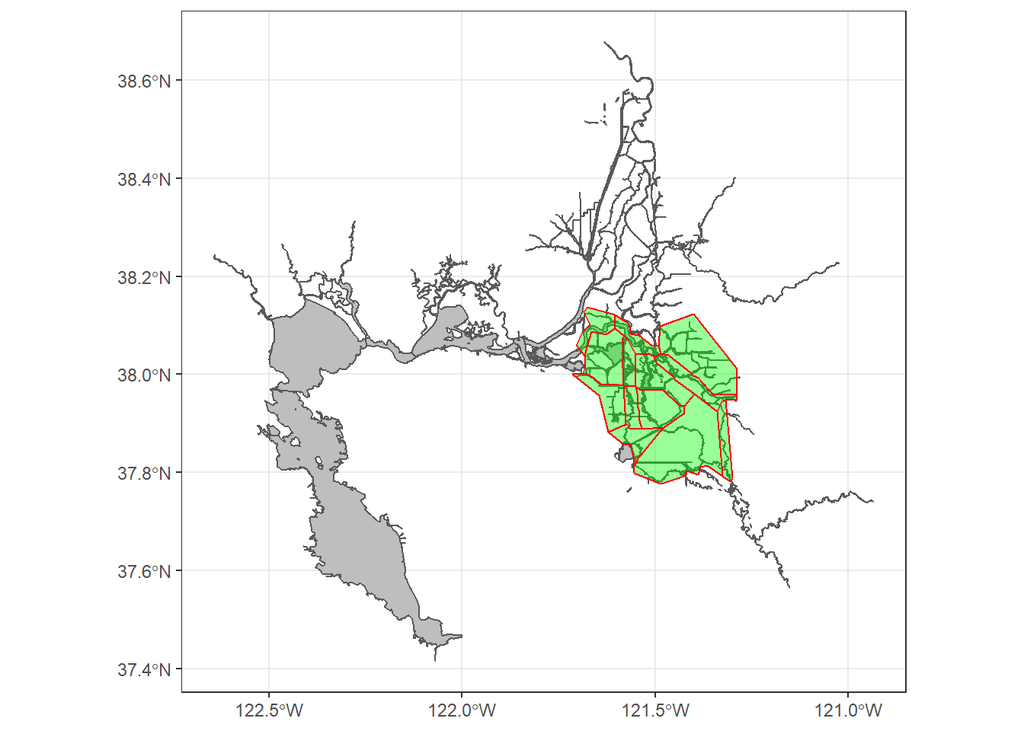

### Adults

| Cohort Year | 0.0% | 5.0% | 10.0% | 90.0% | 95.0% | 100.0% | Sample size |
| --- | --- | --- | --- | --- | --- | --- | --- |
| 1999 | January 07 2000 | January 07 2000 | January 07 2000 | January 07 2000 | January 07 2000 | January 07 2000 | 4 |
| 2000 | December 06 2000 | December 06 2000 | December 06 2000 | January 03 2001 | January 03 2001 | January 03 2001 | 5 |
| 2001 | December 07 2001 | December 07 2001 | December 07 2001 | April 15 2002 | April 15 2002 | April 15 2002 | 4 |
| 2003 | January 05 2004 | January 05 2004 | January 05 2004 | January 05 2004 | January 05 2004 | January 05 2004 | 2 |
| 2008 | January 05 2009 | January 05 2009 | January 05 2009 | January 05 2009 | January 05 2009 | January 05 2009 | 1 |
| 2009 | December 15 2009 | December 15 2009 | December 15 2009 | January 04 2010 | January 04 2010 | January 04 2010 | 3 |
| 2011 | January 03 2012 | January 03 2012 | January 03 2012 | January 03 2012 | January 03 2012 | January 03 2012 | 1 |
| 2012 | January 07 2013 | January 07 2013 | January 07 2013 | January 07 2013 | January 07 2013 | January 07 2013 | 2 |
| 2016 | January 24 2017 | January 24 2017 | January 24 2017 | January 24 2017 | January 24 2017 | January 24 2017 | 1 |
| 2019 | December 02 2019 | December 02 2019 | December 02 2019 | December 02 2019 | December 02 2019 | December 02 2019 | 1 |

### Juveniles

| Cohort Year | 0.0% | 5.0% | 10.0% | 90.0% | 95.0% | 100.0% | Sample size |
| --- | --- | --- | --- | --- | --- | --- | --- |
| 1994 | June 15 1994 | June 15 1994 | June 15 1994 | June 15 1994 | June 15 1994 | June 15 1994 | 1 |
| 1995 | December 04 1995 | December 04 1995 | December 04 1995 | December 04 1995 | December 04 1995 | December 04 1995 | 1 |
| 1996 | April 25 1996 | April 25 1996 | April 25 1996 | April 30 1996 | April 30 1996 | April 30 1996 | 5 |
| 1997 | April 14 1997 | April 14 1997 | April 14 1997 | May 12 1997 | May 12 1997 | May 12 1997 | 8 |
| 1999 | April 12 1999 | April 12 1999 | April 12 1999 | May 11 1999 | May 11 1999 | May 11 1999 | 4 |
| 2000 | May 01 2000 | May 01 2000 | May 01 2000 | December 06 2000 | December 06 2000 | December 06 2000 | 3 |
| 2001 | April 16 2001 | April 16 2001 | April 16 2001 | June 11 2001 | June 11 2001 | June 11 2001 | 6 |
| 2002 | March 18 2002 | April 15 2002 | April 15 2002 | April 29 2002 | May 13 2002 | May 28 2002 | 779 |
| 2003 | March 24 2003 | April 07 2003 | April 07 2003 | April 21 2003 | April 22 2003 | April 22 2003 | 23 |
| 2004 | April 12 2004 | April 12 2004 | April 12 2004 | June 07 2004 | June 07 2004 | June 07 2004 | 5 |
| 2005 | March 14 2005 | March 14 2005 | March 14 2005 | March 14 2005 | March 14 2005 | March 14 2005 | 14 |
| 2006 | May 01 2006 | May 01 2006 | May 01 2006 | May 01 2006 | May 01 2006 | May 01 2006 | 1 |
| 2007 | June 04 2007 | June 04 2007 | June 04 2007 | June 04 2007 | June 04 2007 | June 04 2007 | 1 |
| 2008 | April 14 2008 | April 14 2008 | April 14 2008 | June 30 2008 | June 30 2008 | June 30 2008 | 4 |
| 2010 | March 29 2010 | March 29 2010 | March 29 2010 | May 10 2010 | May 10 2010 | May 10 2010 | 2 |
| 2012 | March 12 2012 | March 12 2012 | March 12 2012 | April 23 2012 | April 23 2012 | April 23 2012 | 6 |
| 2013 | March 25 2013 | April 08 2013 | April 22 2013 | June 10 2013 | June 17 2013 | June 26 2013 | 44 |
| 2014 | March 18 2014 | March 18 2014 | March 18 2014 | April 28 2014 | April 28 2014 | April 28 2014 | 24 |
| 2015 | April 06 2015 | April 06 2015 | April 06 2015 | April 27 2015 | April 27 2015 | April 27 2015 | 9 |
| 2017 | February 10 2017 | February 10 2017 | February 10 2017 | March 07 2017 | March 07 2017 | March 07 2017 | 3 |
| 2019 | February 19 2019 | February 19 2019 | February 19 2019 | December 04 2019 | December 04 2019 | December 04 2019 | 3 |
| 2020 | April 27 2020 | April 27 2020 | April 27 2020 | April 27 2020 | April 27 2020 | April 27 2020 | 1 |
| 2021 | April 05 2021 | April 05 2021 | April 05 2021 | May 18 2021 | May 18 2021 | May 18 2021 | 9 |

### Larvae

| Cohort Year | 0.0% | 5.0% | 10.0% | 90.0% | 95.0% | 100.0% | Sample size |
| --- | --- | --- | --- | --- | --- | --- | --- |
| 1996 | April 24 1996 | April 30 1996 | April 30 1996 | April 30 1996 | April 30 1996 | April 30 1996 | 69 |
| 1997 | March 31 1997 | April 14 1997 | April 14 1997 | April 28 1997 | April 28 1997 | May 12 1997 | 91 |
| 1999 | April 12 1999 | April 12 1999 | April 12 1999 | April 26 1999 | April 26 1999 | April 26 1999 | 6 |
| 2000 | April 03 2000 | April 03 2000 | April 03 2000 | May 22 2000 | June 12 2000 | June 12 2000 | 85 |
| 2001 | March 19 2001 | March 19 2001 | March 19 2001 | April 30 2001 | May 01 2001 | May 29 2001 | 143 |
| 2002 | March 18 2002 | March 18 2002 | April 02 2002 | April 29 2002 | April 29 2002 | May 28 2002 | 1292 |
| 2003 | March 24 2003 | March 24 2003 | March 24 2003 | April 21 2003 | April 21 2003 | May 05 2003 | 135 |
| 2004 | March 29 2004 | March 29 2004 | March 29 2004 | April 13 2004 | April 26 2004 | April 26 2004 | 14 |
| 2005 | March 14 2005 | March 14 2005 | March 14 2005 | March 14 2005 | March 28 2005 | June 21 2005 | 106 |
| 2006 | April 18 2006 | April 18 2006 | April 18 2006 | May 01 2006 | May 01 2006 | May 01 2006 | 9 |
| 2007 | March 26 2007 | March 26 2007 | March 26 2007 | April 23 2007 | April 23 2007 | April 23 2007 | 12 |
| 2008 | March 17 2008 | April 01 2008 | April 01 2008 | April 28 2008 | April 29 2008 | May 27 2008 | 121 |
| 2009 | January 05 2009 | January 20 2009 | January 20 2009 | March 02 2009 | April 06 2009 | April 21 2009 | 437 |
| 2010 | January 04 2010 | January 04 2010 | January 04 2010 | March 01 2010 | March 23 2010 | May 10 2010 | 605 |
| 2011 | January 18 2011 | January 31 2011 | January 31 2011 | February 14 2011 | February 28 2011 | March 22 2011 | 297 |
| 2012 | January 09 2012 | January 09 2012 | January 09 2012 | March 12 2012 | March 19 2012 | May 07 2012 | 705 |
| 2013 | January 02 2013 | January 28 2013 | January 28 2013 | April 08 2013 | April 09 2013 | June 03 2013 | 1130 |
| 2014 | January 06 2014 | January 21 2014 | January 21 2014 | March 18 2014 | April 01 2014 | April 29 2014 | 632 |
| 2015 | January 05 2015 | February 02 2015 | February 02 2015 | April 27 2015 | April 27 2015 | April 27 2015 | 110 |
| 2016 | January 04 2016 | January 04 2016 | January 04 2016 | February 16 2016 | March 14 2016 | March 29 2016 | 49 |
| 2017 | January 17 2017 | January 17 2017 | January 17 2017 | March 13 2017 | March 13 2017 | March 13 2017 | 2 |
| 2018 | January 02 2018 | January 02 2018 | January 02 2018 | February 12 2018 | February 12 2018 | February 12 2018 | 16 |
| 2019 | January 02 2019 | January 02 2019 | January 02 2019 | January 28 2019 | February 11 2019 | February 11 2019 | 11 |
| 2020 | January 06 2020 | January 06 2020 | January 21 2020 | March 17 2020 | March 31 2020 | December 28 2020 | 108 |
| 2021 | January 11 2021 | January 25 2021 | January 25 2021 | April 05 2021 | April 20 2021 | May 18 2021 | 218 |